# Dada2_report

Ramón Gallego

1/9/2018

## Dada2 report

You have successfully split your libraries into a pair (or two) of fastq files per sample. Now let’s import the output of demultiplex_both_fastq.sh

First load the packages. And let’s update the parameters we need

```
## # A tibble: 6 x 3
##   Full_Id                           fastq_header Sample
##   <chr>                             <chr>        <chr>
## 1 ID1=Lib_B;ID2A=GATGAC;ID2B=GTCATC Lib_B_GATGAC SA07A.1
## 2 ID1=Lib_D;ID2A=GATGAC;ID2B=GTCATC Lib_D_GATGAC SA07B.1
## 3 ID1=Lib_B;ID2A=GCGCTC;ID2B=GAGCGC Lib_B_GCGCTC SA07C.1
## 4 ID1=Lib_G;ID2A=CTCGCA;ID2B=TGCGAG Lib_G_CTCGCA TR07A.1
## 5 ID1=Lib_A;ID2A=ACAGCA;ID2B=TGCTGT Lib_A_ACAGCA TR07B.1
## 6 ID1=Lib_B;ID2A=TGTATG;ID2B=CATACA Lib_B_TGTATG TR07C.1
```

```
## [1] "/Users/ramongallego/demultiplexer_for_DADA2/data/Lib-B_S2_L001_R1_001_sub.fastq"
```

Firstly, we’ll find the patterns that separate our Fwd, Rev, .1 and .2 files. look at the quality of the .1 and .2 reads

```r
F1s <- sort(list.files(path1, pattern="_Fwd.1.fastq", full.names = TRUE))
F2s <- sort(list.files(path1, pattern="_Fwd.2.fastq", full.names = TRUE))
R1s <- sort(list.files(path1, pattern="_Rev.1.fastq", full.names = TRUE))
R2s <- sort(list.files(path1, pattern="_Rev.2.fastq", full.names = TRUE))

# Extract sample names, assuming filenames have format: SAMPLENAME_XXX.fastq
sample.names <- str_replace(basename(F1s), "_Fwd.1.fastq","")

#Now use only those that reflect a real sample

good.sample.names<-sample.names[sample.names %in% sample.map$fastq_header]
# Introduce here the biological counterpart of the fastq file

real.sample.name <- sample.map[,3][match(good.sample.names,sample.map$fastq_header),1]

# Now subset the number of files to be looked at

F1sgood<-F1s[sample.names %in% sample.map$fastq_header]
F2sgood<-F2s[sample.names %in% sample.map$fastq_header]
R1sgood<-R1s[sample.names %in% sample.map$fastq_header]
R2sgood<-R2s[sample.names %in% sample.map$fastq_header]
```

A nice idea is to plot the Quality of the F1 reads

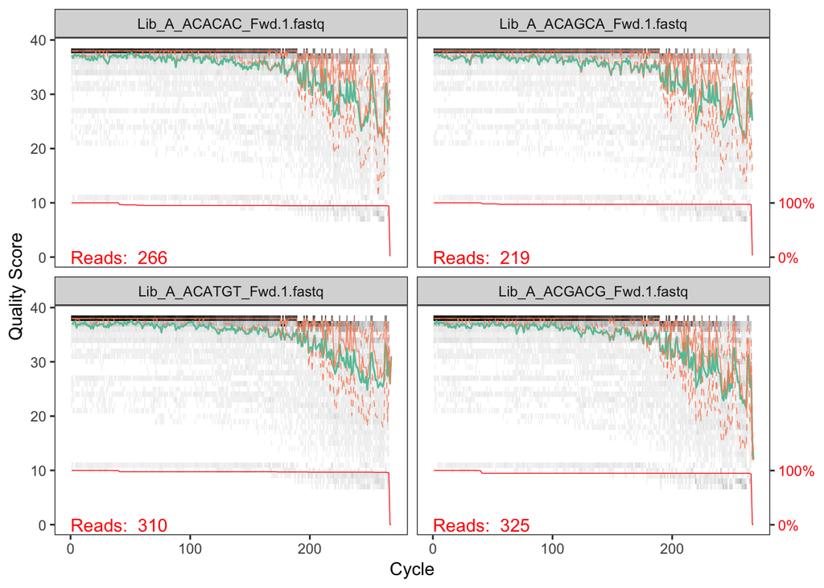

The quality should be similar to that of the Reverse .1 reads

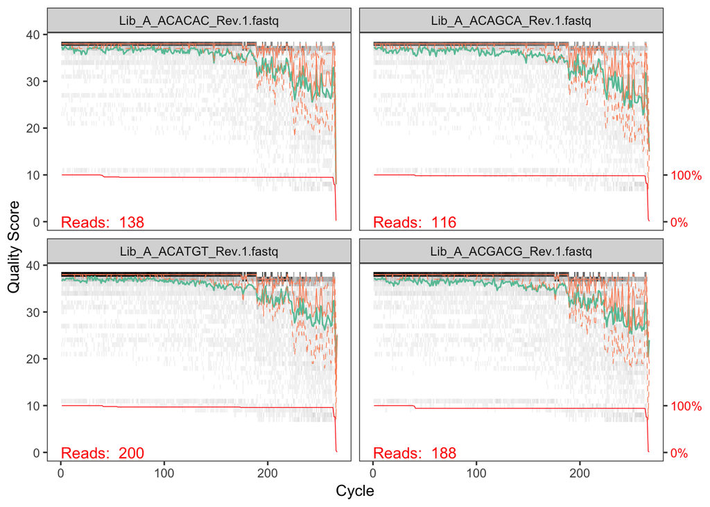

On the other hand, the quality of the .2 reads should decrease earlier

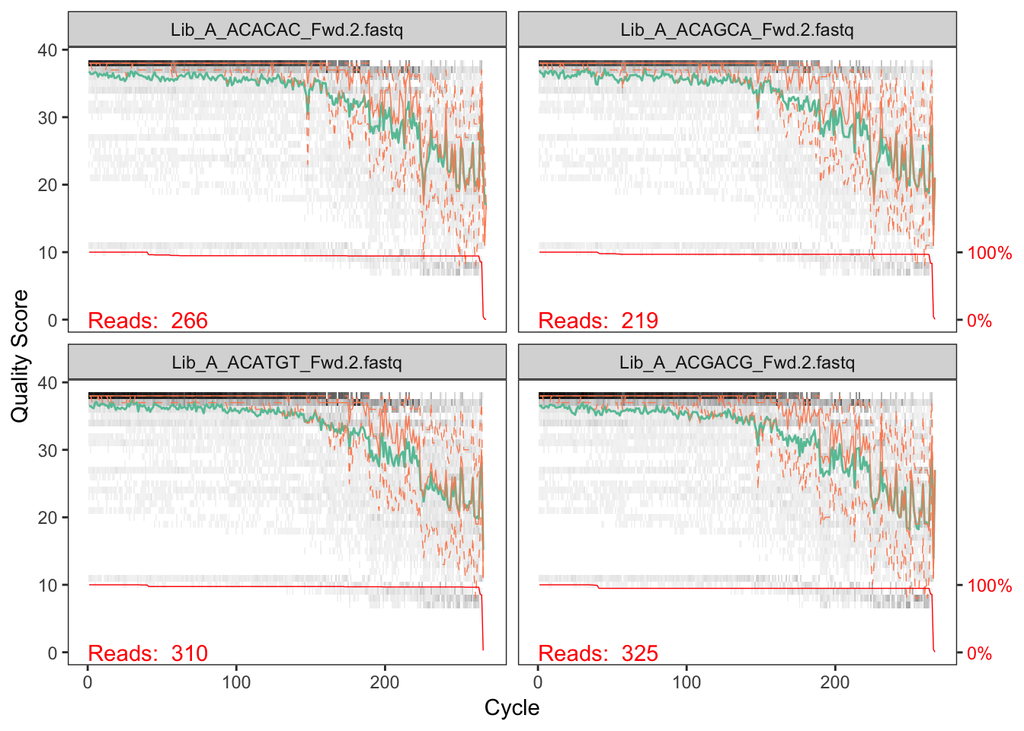

## Now start with the trimming of each read based on the quality we just plotted

```r
filt_path <- file.path(params$folder, "/filtered") # Place filtered files in filtered/ subdirectory
filtF1s <- file.path(filt_path, paste0(good.sample.names, "_F1_filt.fastq.gz"))
filtF2s <- file.path(filt_path, paste0(good.sample.names, "_F2_filt.fastq.gz"))
out_Fs <- filterAndTrim(F1sgood, filtF1s, F2sgood, filtF2s, truncLen=c(200,200),
                      maxN=0, maxEE=c(2,2), truncQ=2, rm.phix=TRUE,
                      compress=TRUE, multithread=TRUE) # On Windows set multithread=FALSE
```

```
## Creating output directory: /Users/ramongallego/fastqs_demultiplexed_for_DADA2/demultiplexed_20180827_1620//filtered
```

```r
filtR1s <- file.path(filt_path, paste0(good.sample.names, "_R1_filt.fastq.gz"))
filtR2s <- file.path(filt_path, paste0(good.sample.names, "_R2_filt.fastq.gz"))
out_Rs <- filterAndTrim(R1sgood, filtR1s, R2sgood, filtR2s, truncLen=c(200,200),
                      maxN=0, maxEE=c(2,2), truncQ=2, rm.phix=TRUE,
                      compress=TRUE, multithread=TRUE)
```

```r
out_Fs_tibble<-tibble(file=dimnames(out_Fs)[[1]], reads.out=out_Fs[,2])
out_Rs_tibble<-tibble(file=dimnames(out_Rs)[[1]], reads.out=out_Rs[,2])
out_Fs_tibble
```

```
## # A tibble: 93 x 2
##    file                     reads.out
##    <chr>                        <dbl>
##  1 Lib_A_ACACAC_Fwd.1.fastq       218
##  2 Lib_A_ACAGCA_Fwd.1.fastq       184
##  3 Lib_A_ACATGT_Fwd.1.fastq       261
##  4 Lib_A_ACGACG_Fwd.1.fastq       253
##  5 Lib_A_ATATCG_Fwd.1.fastq       158
##  6 Lib_A_CGACGC_Fwd.1.fastq       211
##  7 Lib_A_CTCGCA_Fwd.1.fastq       323
##  8 Lib_A_GATGAC_Fwd.1.fastq       127
##  9 Lib_A_GCAGTG_Fwd.1.fastq       156
## 10 Lib_A_GCGCTC_Fwd.1.fastq       125
## # ... with 83 more rows
```

Now the first crucial step: learning the error rates that would be different for fwd and rev reads

```r
errF1 <- learnErrors(filtF1s, multithread=TRUE,verbose = 0)
errF2 <- learnErrors(filtF2s, multithread=TRUE,verbose = 0)
errR1 <- learnErrors(filtR1s, multithread=TRUE,verbose = 0)
errR2 <- learnErrors(filtR2s, multithread=TRUE,verbose = 0)
```

Which we can plot now to see the error rates between transitions of each pair of nt

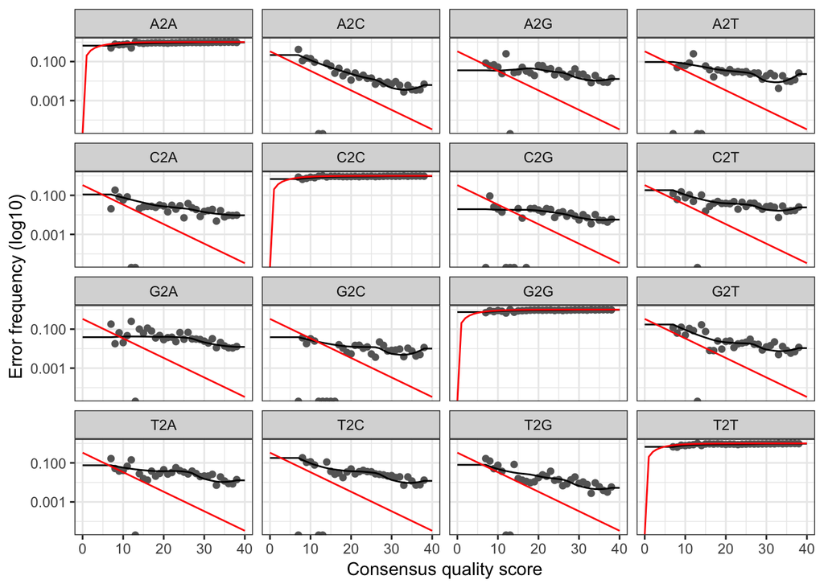

```r
plotErrors(errF1, nominalQ = T)
```

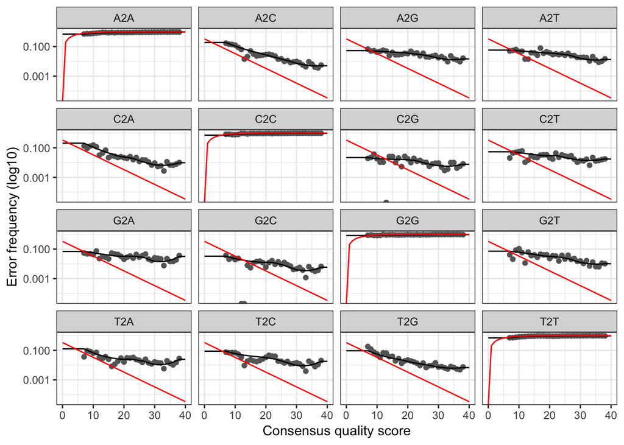

```r
plotErrors(errF2, nominalQ = T)
```

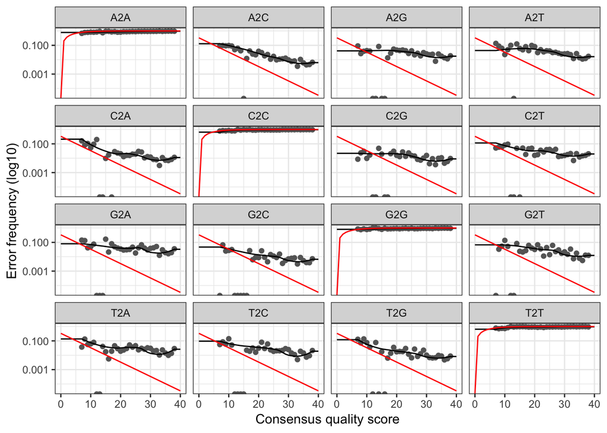

```r
plotErrors(errR1, nominalQ = T)
```

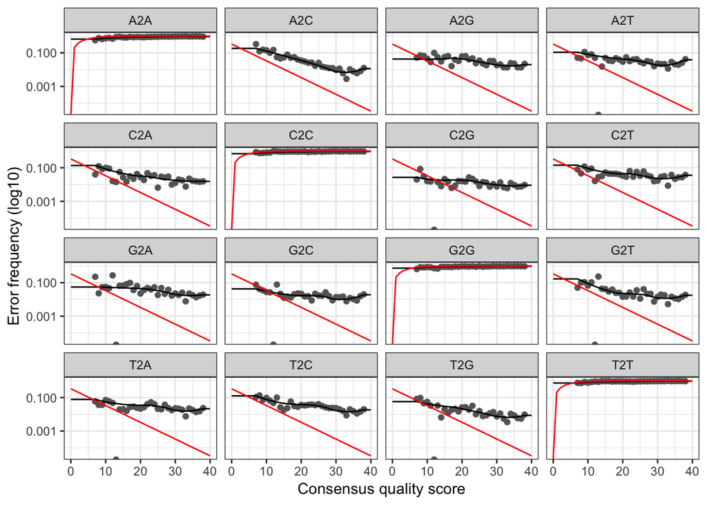

```r
plotErrors(errR2, nominalQ = T)
```

## Now go to the dereplication step

## And finally an inference of the sample composition

```r
dadaF1s <- dada(derepF1s, err = errF1, multithread = TRUE)
```

```
## Sample 1 - 218 reads in 111 unique sequences.
## Sample 2 - 184 reads in 85 unique sequences.
## Sample 3 - 261 reads in 147 unique sequences.
## Sample 4 - 253 reads in 112 unique sequences.
## Sample 5 - 158 reads in 83 unique sequences.
## Sample 6 - 211 reads in 121 unique sequences.
## Sample 7 - 323 reads in 156 unique sequences.
## Sample 8 - 127 reads in 82 unique sequences.
## Sample 9 - 156 reads in 112 unique sequences.
## Sample 10 - 125 reads in 70 unique sequences.
## Sample 11 - 250 reads in 123 unique sequences.
## Sample 12 - 308 reads in 175 unique sequences.
## Sample 13 - 246 reads in 108 unique sequences.
## Sample 14 - 231 reads in 157 unique sequences.
## Sample 15 - 256 reads in 137 unique sequences.
## Sample 16 - 228 reads in 145 unique sequences.
## Sample 17 - 222 reads in 111 unique sequences.
## Sample 18 - 184 reads in 108 unique sequences.
## Sample 19 - 204 reads in 123 unique sequences.
## Sample 20 - 193 reads in 103 unique sequences.
## Sample 21 - 245 reads in 142 unique sequences.
## Sample 22 - 148 reads in 78 unique sequences.
## Sample 23 - 161 reads in 87 unique sequences.
## Sample 24 - 207 reads in 105 unique sequences.
## Sample 25 - 225 reads in 99 unique sequences.
## Sample 26 - 173 reads in 115 unique sequences.
## Sample 27 - 223 reads in 98 unique sequences.
## Sample 28 - 169 reads in 85 unique sequences.
## Sample 29 - 186 reads in 109 unique sequences.
## Sample 30 - 219 reads in 116 unique sequences.
## Sample 31 - 159 reads in 104 unique sequences.
## Sample 32 - 202 reads in 86 unique sequences.
## Sample 33 - 270 reads in 111 unique sequences.
## Sample 34 - 204 reads in 88 unique sequences.
## Sample 35 - 153 reads in 69 unique sequences.
## Sample 36 - 128 reads in 85 unique sequences.
## Sample 37 - 127 reads in 95 unique sequences.
## Sample 38 - 276 reads in 179 unique sequences.
## Sample 39 - 126 reads in 70 unique sequences.
## Sample 40 - 104 reads in 47 unique sequences.
```

[output cut: 38 more lines]

```
## Sample 79 - 156 reads in 84 unique sequences.
## Sample 80 - 123 reads in 77 unique sequences.
## Sample 81 - 193 reads in 86 unique sequences.
## Sample 82 - 168 reads in 105 unique sequences.
## Sample 83 - 178 reads in 83 unique sequences.
## Sample 84 - 189 reads in 116 unique sequences.
## Sample 85 - 159 reads in 86 unique sequences.
## Sample 86 - 259 reads in 123 unique sequences.
## Sample 87 - 161 reads in 87 unique sequences.
## Sample 88 - 135 reads in 65 unique sequences.
## Sample 89 - 266 reads in 152 unique sequences.
## Sample 90 - 178 reads in 98 unique sequences.
## Sample 91 - 267 reads in 124 unique sequences.
## Sample 92 - 192 reads in 113 unique sequences.
## Sample 93 - 246 reads in 109 unique sequences.
```

```r
dadaF2s <- dada(derepF2s, err = errF2, multithread = TRUE)
```

```
## Sample 1 - 218 reads in 124 unique sequences.
## Sample 2 - 184 reads in 106 unique sequences.
## Sample 3 - 261 reads in 160 unique sequences.
## Sample 4 - 253 reads in 129 unique sequences.
## Sample 5 - 158 reads in 83 unique sequences.
## Sample 6 - 211 reads in 126 unique sequences.
## Sample 7 - 323 reads in 186 unique sequences.
## Sample 8 - 127 reads in 85 unique sequences.
## Sample 9 - 156 reads in 119 unique sequences.
## Sample 10 - 125 reads in 83 unique sequences.
## Sample 11 - 250 reads in 149 unique sequences.
## Sample 12 - 308 reads in 192 unique sequences.
## Sample 13 - 246 reads in 116 unique sequences.
## Sample 14 - 231 reads in 179 unique sequences.
## Sample 15 - 256 reads in 158 unique sequences.
## Sample 16 - 228 reads in 151 unique sequences.
## Sample 17 - 222 reads in 123 unique sequences.
## Sample 18 - 184 reads in 122 unique sequences.
## Sample 19 - 204 reads in 122 unique sequences.
## Sample 20 - 193 reads in 121 unique sequences.
## Sample 21 - 245 reads in 167 unique sequences.
## Sample 22 - 148 reads in 88 unique sequences.
## Sample 23 - 161 reads in 107 unique sequences.
## Sample 24 - 207 reads in 108 unique sequences.
## Sample 25 - 225 reads in 107 unique sequences.
## Sample 26 - 173 reads in 128 unique sequences.
## Sample 27 - 223 reads in 119 unique sequences.
## Sample 28 - 169 reads in 85 unique sequences.
## Sample 29 - 186 reads in 109 unique sequences.
## Sample 30 - 219 reads in 106 unique sequences.
## Sample 31 - 159 reads in 119 unique sequences.
## Sample 32 - 202 reads in 105 unique sequences.
## Sample 33 - 270 reads in 136 unique sequences.
## Sample 34 - 204 reads in 100 unique sequences.
## Sample 35 - 153 reads in 67 unique sequences.
## Sample 36 - 128 reads in 91 unique sequences.
## Sample 37 - 127 reads in 93 unique sequences.
## Sample 38 - 276 reads in 177 unique sequences.
## Sample 39 - 126 reads in 83 unique sequences.
## Sample 40 - 104 reads in 85 unique sequences.
```

[output cut: 38 more lines]

```
## Sample 79 - 156 reads in 84 unique sequences.
## Sample 80 - 123 reads in 76 unique sequences.
## Sample 81 - 193 reads in 102 unique sequences.
## Sample 82 - 168 reads in 124 unique sequences.
## Sample 83 - 178 reads in 108 unique sequences.
## Sample 84 - 189 reads in 133 unique sequences.
## Sample 85 - 159 reads in 92 unique sequences.
## Sample 86 - 259 reads in 150 unique sequences.
## Sample 87 - 161 reads in 103 unique sequences.
## Sample 88 - 135 reads in 72 unique sequences.
## Sample 89 - 266 reads in 159 unique sequences.
## Sample 90 - 178 reads in 120 unique sequences.
## Sample 91 - 267 reads in 153 unique sequences.
## Sample 92 - 192 reads in 126 unique sequences.
## Sample 93 - 246 reads in 156 unique sequences.
```

```r
dadaR1s <- dada(derepR1s, err = errR1, multithread = TRUE)
```

```
## Sample 1 - 108 reads in 50 unique sequences.
## Sample 2 - 90 reads in 50 unique sequences.
## Sample 3 - 162 reads in 100 unique sequences.
## Sample 4 - 144 reads in 72 unique sequences.
## Sample 5 - 89 reads in 51 unique sequences.
## Sample 6 - 109 reads in 70 unique sequences.
## Sample 7 - 184 reads in 90 unique sequences.
## Sample 8 - 54 reads in 43 unique sequences.
## Sample 9 - 111 reads in 62 unique sequences.
## Sample 10 - 70 reads in 50 unique sequences.
## Sample 11 - 154 reads in 80 unique sequences.
## Sample 12 - 119 reads in 72 unique sequences.
## Sample 13 - 121 reads in 56 unique sequences.
## Sample 14 - 89 reads in 58 unique sequences.
## Sample 15 - 116 reads in 73 unique sequences.
## Sample 16 - 132 reads in 85 unique sequences.
## Sample 17 - 134 reads in 76 unique sequences.
## Sample 18 - 87 reads in 43 unique sequences.
## Sample 19 - 145 reads in 77 unique sequences.
## Sample 20 - 129 reads in 65 unique sequences.
## Sample 21 - 124 reads in 75 unique sequences.
## Sample 22 - 66 reads in 35 unique sequences.
## Sample 23 - 134 reads in 66 unique sequences.
## Sample 24 - 107 reads in 55 unique sequences.
## Sample 25 - 130 reads in 57 unique sequences.
## Sample 26 - 53 reads in 34 unique sequences.
## Sample 27 - 114 reads in 51 unique sequences.
## Sample 28 - 75 reads in 35 unique sequences.
## Sample 29 - 96 reads in 55 unique sequences.
## Sample 30 - 132 reads in 75 unique sequences.
## Sample 31 - 95 reads in 63 unique sequences.
## Sample 32 - 121 reads in 50 unique sequences.
## Sample 33 - 202 reads in 99 unique sequences.
## Sample 34 - 128 reads in 53 unique sequences.
## Sample 35 - 58 reads in 28 unique sequences.
## Sample 36 - 111 reads in 74 unique sequences.
## Sample 37 - 72 reads in 53 unique sequences.
## Sample 38 - 156 reads in 98 unique sequences.
## Sample 39 - 85 reads in 49 unique sequences.
## Sample 40 - 44 reads in 23 unique sequences.
```

[output cut: 38 more lines]

```
## Sample 79 - 71 reads in 31 unique sequences.
## Sample 80 - 83 reads in 53 unique sequences.
## Sample 81 - 106 reads in 46 unique sequences.
## Sample 82 - 96 reads in 62 unique sequences.
## Sample 83 - 108 reads in 55 unique sequences.
## Sample 84 - 106 reads in 72 unique sequences.
## Sample 85 - 82 reads in 36 unique sequences.
## Sample 86 - 168 reads in 91 unique sequences.
## Sample 87 - 102 reads in 45 unique sequences.
## Sample 88 - 82 reads in 32 unique sequences.
## Sample 89 - 87 reads in 55 unique sequences.
## Sample 90 - 171 reads in 108 unique sequences.
## Sample 91 - 148 reads in 62 unique sequences.
## Sample 92 - 123 reads in 68 unique sequences.
## Sample 93 - 175 reads in 99 unique sequences.
```

```r
dadaR2s <- dada(derepR2s, err = errR2, multithread = TRUE)
```

```
## Sample 1 - 108 reads in 71 unique sequences.
## Sample 2 - 90 reads in 58 unique sequences.
## Sample 3 - 162 reads in 118 unique sequences.
## Sample 4 - 144 reads in 92 unique sequences.
## Sample 5 - 89 reads in 64 unique sequences.
## Sample 6 - 109 reads in 80 unique sequences.
## Sample 7 - 184 reads in 106 unique sequences.
## Sample 8 - 54 reads in 41 unique sequences.
## Sample 9 - 111 reads in 73 unique sequences.
## Sample 10 - 70 reads in 53 unique sequences.
## Sample 11 - 154 reads in 102 unique sequences.
## Sample 12 - 119 reads in 83 unique sequences.
## Sample 13 - 121 reads in 65 unique sequences.
## Sample 14 - 89 reads in 72 unique sequences.
## Sample 15 - 116 reads in 80 unique sequences.
## Sample 16 - 132 reads in 105 unique sequences.
## Sample 17 - 134 reads in 93 unique sequences.
## Sample 18 - 87 reads in 58 unique sequences.
## Sample 19 - 145 reads in 96 unique sequences.
## Sample 20 - 129 reads in 93 unique sequences.
## Sample 21 - 124 reads in 93 unique sequences.
## Sample 22 - 66 reads in 34 unique sequences.
## Sample 23 - 134 reads in 77 unique sequences.
## Sample 24 - 107 reads in 69 unique sequences.
## Sample 25 - 130 reads in 68 unique sequences.
## Sample 26 - 53 reads in 42 unique sequences.
## Sample 27 - 114 reads in 69 unique sequences.
## Sample 28 - 75 reads in 46 unique sequences.
## Sample 29 - 96 reads in 69 unique sequences.
## Sample 30 - 132 reads in 91 unique sequences.
## Sample 31 - 95 reads in 77 unique sequences.
## Sample 32 - 121 reads in 66 unique sequences.
## Sample 33 - 202 reads in 120 unique sequences.
## Sample 34 - 128 reads in 75 unique sequences.
## Sample 35 - 58 reads in 36 unique sequences.
## Sample 36 - 111 reads in 83 unique sequences.
## Sample 37 - 72 reads in 62 unique sequences.
## Sample 38 - 156 reads in 118 unique sequences.
## Sample 39 - 85 reads in 57 unique sequences.
## Sample 40 - 44 reads in 34 unique sequences.
```

[output cut: 38 more lines]

```
## Sample 79 - 71 reads in 38 unique sequences.
## Sample 80 - 83 reads in 65 unique sequences.
## Sample 81 - 106 reads in 71 unique sequences.
## Sample 82 - 96 reads in 74 unique sequences.
## Sample 83 - 108 reads in 67 unique sequences.
## Sample 84 - 106 reads in 85 unique sequences.
## Sample 85 - 82 reads in 52 unique sequences.
## Sample 86 - 168 reads in 119 unique sequences.
## Sample 87 - 102 reads in 70 unique sequences.
## Sample 88 - 82 reads in 50 unique sequences.
## Sample 89 - 87 reads in 67 unique sequences.
## Sample 90 - 171 reads in 116 unique sequences.
## Sample 91 - 148 reads in 99 unique sequences.
## Sample 92 - 123 reads in 88 unique sequences.
## Sample 93 - 175 reads in 110 unique sequences.
```

## We are ready now to merge reads - using the denoised reads and the derep files

```r
mergersF <- mergePairs(dadaF1s, derepF1s, dadaF2s, derepF2s,verbose = 0)

#Run a for loop that adds the number of unique reads that went into each ASV

for (j in 1:length(mergersF)){

  dadaF1s[[j]]@.Data[[2]] %>% rownames_to_column(var="forward") %>% select("forward", "nunq") ->Fwd
  Fwd$forward<-as.integer(Fwd$forward)
  dadaF2s[[j]]@.Data[[2]] %>% rownames_to_column(var="reverse") %>% select("reverse", "nunq") ->Rev
  Rev$reverse<-as.integer(Rev$reverse)

  mergersF[[j]] <- left_join(mergersF[[j]],Fwd, by="forward") %>% left_join(Rev, by="reverse") %>% mutate(nunq=pmin(nunq.x,nunq.y)) %>% select(-nunq.x,-nunq.y)


}

mergersR <- mergePairs(dadaR1s, derepR1s, dadaR2s, derepR2s, verbose = 0)

for (j in 1:length(mergersR)){

  dadaR1s[[j]]@.Data[[2]] %>% rownames_to_column(var="forward") %>% select("forward", "nunq") ->Fwd
  Fwd$forward<-as.integer(Fwd$forward)
  dadaR2s[[j]]@.Data[[2]] %>% rownames_to_column(var="reverse") %>% select("reverse", "nunq") ->Rev
  Rev$reverse<-as.integer(Rev$reverse)

  mergersR[[j]] <- left_join(mergersR[[j]],Fwd, by="forward") %>% left_join(Rev, by="reverse") %>% mutate(nunq=pmin(nunq.x,nunq.y)) %>% select(-nunq.x,-nunq.y)

}
```

## Now we have to merge the Forward and Reverse Reads to make a unique object

Step 1 is to create sequence tables for each direction, seqtabF and seqtabR

```r
seqtabF <- makeSequenceTable(mergersF)
```

```
## The sequences being tabled vary in length.
```

```r
dim(seqtabF)
```

```
## [1] 93 97
```

```r
table(nchar(getSequences(seqtabF)))
```

```
##
## 304 310 311 312 313 316 319 349 352 355
##   4   1   2   1  78   2   5   1   2   1
```

```r
seqtabR <- makeSequenceTable(mergersR)
```

```
## The sequences being tabled vary in length.
```

```r
dim(seqtabR)
```

```
## [1] 93 61
```

```r
table(nchar(getSequences(seqtabR)))
```

```
##
## 304 310 311 312 313 316 319 355
##   2   1   1   2  45   2   7   1
```

Step 2 is to reverse complement the reverse reads, and checking how many of the reads in F were present in R (if you get a 0 means we have done something wrong). Lastly, we change the reverse sequences and add their Reverse complement instead

```r
reversed_sequences<-as.character(reverseComplement(DNAStringSet(colnames(seqtabR))))

summary (colnames(seqtabF) %in% reversed_sequences)
```

```
##    Mode   FALSE    TRUE
## logical      59      38
```

```r
summary (reversed_sequences %in% colnames(seqtabF))
```

```
##    Mode   FALSE    TRUE
## logical      23      38
```

```r
colnames(seqtabR)<-reversed_sequences
```

Step 3 does the actual merging and returns another sequence Table

```r
seqtab.R.df=as.data.frame(seqtabR)

final.seqtab<-data.frame(row.names = rownames(seqtabF))


for (i in 1:ncol(seqtabF)) {   #for each column of the first dataframe

  current_seq<-colnames(seqtabF)[i]

  if (current_seq %in% colnames(seqtab.R.df)) { # is that column present on the second df?

    final.seqtab[,current_seq]<-seqtabF[,i] + seqtab.R.df[,current_seq] #if yes, the new df has the sum of reads

    seqtab.R.df[,current_seq]<-NULL
    #seqtab.R2.df<- seqtab.R2.df[,-current_seq] #we delete the column from the second df to speed up next search


  } else {        # if the column is not present, then the new df is the value of the first df

    final.seqtab[,current_seq] <- seqtabF[,i]

  }



}
# Now cbind both dataset
final.seqtab <- as.matrix (cbind(final.seqtab,seqtab.R.df))
```

## Now get rid of the chimeras

```r
seqtab.nochim <- removeBimeraDenovo(final.seqtab, method="consensus", multithread=TRUE)

dim(seqtab.nochim)
```

```
## [1]  93 119
```

## Now it is a good time to check whether the sequences are in the Fwd or Reverse-ReverseComplement direction, we’ll use 500 sequences to make up our test

```r
ifelse(length(colnames(seqtab.nochim))>500, to_write<- sample(colnames(seqtab.nochim),size = 500, replace = F), to_write<-colnames(seqtab.nochim))
```

```
## [1] "TTTAAGTGGAATCCTAGCACATTCTGGAGGATCTGTAGATCTTGCAATTTTTAGTTTACA…"
```

```r
#to_write<- sample(colnames(seqtab.nochim),size = 500, replace = F)
write_lines(to_write, path = "seqnames.txt")
getwd()
```

```
## [1] "/Users/ramongallego/fastqs_demultiplexed_for_DADA2/demultiplexed_20180827_1620"
```

```bash
#This looks for the sequences of interest in the .1 .2 fastqs, returns only the nt before the match (ie, the primer)

F1_found=matchesF.txt
F2_found=matchesR.txt

cat seqnames.txt | cut -c 1-120 | xargs -I '{}' sed -n 's/{}.*$//p' "${READ1}" > "${F1_found}"

cat seqnames.txt | cut -c 1-120 | xargs -I '{}' sed -n 's/{}.*$//p' "${READ2}" > "${F2_found}"

#This looks in those files for the Fwd and Rev PCR primers - we only should get the fwd primer

COIF=$(head -2 pcr_primers.fasta | tail -1 | sed 's/[^ACGT]/\[A-Z]/g')
COIR=$(head -4 pcr_primers.fasta | tail -1 | sed 's/[^ACGT]/\[A-Z]/g')

echo "${COIF}"

matchesF1=$(grep "${COIF}" "${F1_found}" --count)
matchesRRC1=$(grep "${COIR}" "${F1_found}" --count)
matchesF2=$(grep "${COIF}" "${F2_found}" --count)
matchesRRC2=$(grep "${COIR}" "${F2_found}" --count)

echo "${matchesF1}" "${matchesRRC1}" "${matchesF2}" "${matchesRRC2}"

printf "Fwd_Primer\tfile.1\t%s\nRev_Primer\tfile.1\t%s\nFwd_Primer\tfile.2\t%s\nRev_Primer\tfile.2\t%s\n" \
 "${matchesF1}" "${matchesRRC1}" "${matchesF2}" "${matchesRRC2}" >matches.txt
```

```
## GG[A-Z]AC[A-Z]GG[A-Z]TGAAC[A-Z]GT[A-Z]TA[A-Z]CC[A-Z]CC
## 4819 0 2284 0
```

#Now hoping these objects are available for R to import

```r
results_search=read_delim("matches.txt", delim = "\t", col_names = c("Primer","File", "nMatches"))
results_search
```

```
## # A tibble: 4 x 3
##   Primer     File   nMatches
##   <chr>      <chr>     <int>
## 1 Fwd_Primer file.1     4819
## 2 Rev_Primer file.1        0
## 3 Fwd_Primer file.2     2284
## 4 Rev_Primer file.2        0
```

```r
results_search %>% group_by(Primer) %>% summarise(Total=sum(nMatches)) %>% pull (Total)-> results_spread
names(results_spread) <- results_search %>% group_by(Primer) %>% summarise(Total=sum(nMatches)) %>% pull (1)

results_spread
```

```
## Fwd_Primer Rev_Primer
##       7103          0
```

```r
direction=NULL

# So here is my solution: If all or 99% of the reads are Fwd - then we assume they are all Fwd and no RC is needed
# If all or 99% of the reads are Reverse Complemented - then I assumy they are all RC and we'll proceed with revcom
# IF there is more than 1% difference then we'll call it mixed and throw a warning message and don't do anything

ifelse(results_spread["Rev_Primer"]==0 | (results_spread["Fwd_Primer"] / results_spread["Rev_Primer"])>100, yes = direction<-"Fwd",
     ifelse(results_spread["Fwd_Primer"]==0 | (results_spread["Rev_Primer"] / results_spread["Fwd_Primer"])>100, yes = direction<-"Rev", no = direction<-"MIXED"))
```

```
## Rev_Primer
##      "Fwd"
```

```r
direction
```

```
## [1] "Fwd"
```

## IF selected, proceed with Hashing: create a hash conversion table and saving files in tidyr format

We are going to keep the info in a tidyr format and save it into a csv file

```r
seqtab.nochim.df=as.data.frame(seqtab.nochim)

if (direction == "MIXED") {

  print(" Seems like some of your reads are in the Fwd direction but others are Reverse Complemented - You should look into that")
}

if (direction == "Rev") {

  print(" Seems like your reads are in the Reverse Complemented direction - I'm going to fix that for you ")

  reversed_sequences<-as.character(reverseComplement(DNAStringSet(colnames(seqtab.nochim.df))))

colnames(seqtab.nochim.df)<-reversed_sequences

}

if (direction == "Fwd") {

  print ("All your reads are in the Fwd direction - Congratulations")
}
```

```
## [1] "All your reads are in the Fwd direction - Congratulations"
```

```r
# Now decide if you want hashing or not

if (grepl ("yes", params$hash, ignore.case = TRUE)) {

  conv_file = paste0(params$folder,"/hash_key.csv")

  conv_table <- tibble( Hash = "", Sequence ="")

  hashes <- list(NULL)

  for (i in 1:ncol(seqtab.nochim.df)) {   #for each column of the dataframe

    current_seq <-colnames(seqtab.nochim.df)[i]

    current_hash <- digest(current_seq,algo = "sha1",serialize = F,skip = "auto")

    hashes[[i]] = current_hash

    conv_table [i,]<-c(current_hash, current_seq)

    colnames(seqtab.nochim.df)[i] <- current_hash

  }

  write_csv(conv_table, conv_file)


seqtab.nochim.df$sample=rownames(seqtab.nochim.df)

 gather(seqtab.nochim.df, key=Hash, value = nReads, -sample) %>%
  filter(nReads > 0) -> current_asv

write_csv(current_asv, paste0(params$folder,"/ASV_table.csv"))
} else { #What do we do if you don't want hashes: two things - Change the header of the ASV table, write only one file

  seqtab.nochim.df$sample=rownames(seqtab.nochim.df)

  gather(seqtab.nochim.df, key=Sequence, value = nReads, -sample) %>%
   filter(nReads > 0) -> current_asv
  write_csv(current_asv, paste0(params$folder,"/ASV_table.csv"))
}
```

## Merge with a previous analysis if selected

If we have chosen to merge our dataset with a previous run, we need to gather that info, and merge properly both datasets.

```r
if (grepl ("yes", params$cont[1], ignore.case = TRUE)) {

old_hash = read_csv(params$cont[2])

old_asv = read_csv(params$cont[3])

all_hash = union_all(old_hash, conv_table)

new.hashes = setdiff(conv_table,old_hash)

reads.new.hashes <- left_join(new.hashes, current_asv, by = c("Hash" = "Sequence"))

all_asv = bind_rows (old_asv, current_asv)

merging.output = tibble(Date = Sys.Date(), Old_db = params$cont[2], Old_ASV = params$cont[3],
                        Input_folder= params$folder, Nseq_old_db = nrow(old_hash), Nseq_new_input = nrow(conv_table),
                        Nseq_new_db = nrow(all_hash), N_newseq = nrow(new.hashes), Nreads_newseq = sum(reads.new.hashes$nReads) )
ifelse(file.exists(params$cont[4]),
       write_csv(merging.output, params$cont[4], append = T),
       write_csv(merging.output, params$cont[4]) )

write_csv(all_hash, paste0(params$folder, "/Hash_db_",Sys.Date(),".csv"))
write_csv(all_asv, paste0(params$folder, "/ASV_all_",Sys.Date(),".csv"))

}
```

##Track the fate of all reads

```r
getN <- function(x) sum(getUniques(x))
track <- as.data.frame(cbind(out_Fs, out_Rs,
                             sapply(dadaF1s, getN), sapply(dadaR1s, getN),
                             sapply(mergersF, getN),sapply(mergersR, getN),
                             rowSums(seqtabF),rowSums(seqtabR),
                             rowSums(final.seqtab), rowSums(seqtab.nochim)))
# If processing a single sample, remove the sapply calls: e.g. replace sapply(dadaFs, getN) with getN(dadaFs)
colnames(track) <- c("input_F", "input_R", "filtered_F","filtered_R",
                     "denoised_F", "denoised_R",
                     "merged_F", "merged_R",
                     "tabled_F", "tabled_R",
                     "tabled_together", "nonchim")

write_csv(track, paste0(params$folder,"/dada2_summary.csv"))
```